# CustomerChurnANNScientificComputingII_273784

### Customer Churn Prediction using ANN

##### Churn is defined as the loss of a customer or a client from any bussiness. Churn rate is a measure of the number of customers leaving a collective group over a specific period. Traditionally, bussinesses can only know about the customers leaving only when they show their intentions to the company then customer retention is the solution to customer churn by providing different offers or the best solution possible. Churn prediction analysis is critical to predict the possiblity of a customer leaving even before they express their intentations. The companies can offer or improve the current services to retain their customers. The goal is to understand and take steps to change it before the costumer gives up the product or service. The customer data can be analyze the pattern or any important information to predict the customer churn. We can use classification algorithm or Artificial Neural Network model to make those prediction.

##### Data Source : https://www.kaggle.com/blastchar/telco-customer-churn

#### Data Dictionary:

##### customerID : Unique Customer ID

##### gender : Gender of the Customer(male or female)

##### SeniorCitizen : Whether the customer is a senior citizen or not (1, 0)

##### Partner : Whether the customer has a partner or not (Yes, No)

##### Dependents : Whether the customer has dependents or not (Yes, No)

##### tenure : Number of months the customer is with the company

##### PhoneService : Whether the customer has a phone service or not (Yes, No)

##### MultipleLines : Whether the customer has multiple lines or not (Yes, No, No phone service)

##### InternetService : Customer’s internet service provider (DSL, Fiber optic, No)

##### OnlineSecurity : Whether the customer has online security or not (Yes, No, No internet service)

##### OnlineBackup : Whether the customer has online backup or not (Yes, No, No internet service)

##### DeviceProtection : Whether the customer has device protection or not (Yes, No, No internet service)

##### TechSupport : Whether the customer has tech support or not (Yes, No, No internet service)

##### StreamingTV : Whether the customer has streaming TV or not (Yes, No, No internet service)

##### StreamingMovies : Whether the customer has streaming movies or not (Yes, No, No internet service)

##### Contract : The contract term of the customer (Month-to-month, One year, Two year)

##### PaperlessBilling : The statys of paperless billing (Yes, No)

##### PaymentMethod : Payment method (Electronic check, Mailed check, Bank transfer (automatic), Credit card (automatic) used by customer

##### MonthlyCharges : The monthly amount charged to the customer

##### TotalCharges : The total amount charged to the customer

##### Churn : Whether the customer churned or not (Yes or No)(Target Variable)

```python
# Libraries for Data Analysis

import pandas as pd
import numpy as np
```

```python
# Libraries for data visualization

import matplotlib.pyplot as plt
import seaborn as sns
%matplotlib inline
```

```python
# Libraries for data scaling and modelling

from sklearn import preprocessing
from sklearn.model_selection import train_test_split

import tensorflow as tf
import keras
from keras.models import Sequential
from keras.layers import Activation
from keras.layers.core import Dense
from keras.optimizers import Adam
from keras.metrics import categorical_crossentropy

# Libraries for model performance analysis

from sklearn.metrics import confusion_matrix, classification_report, accuracy_score

import warnings
warnings.simplefilter('ignore')
```

```python
# Read the data
df = pd.read_csv('C:/Users/itsni\OneDrive - Harrisburg University/Semester 3/scientific computing 2/Project/Telco-Customer-Churn-Data.csv')
```

##### Data Analysis

```python
df.head()
```

|  | customerID | gender | SeniorCitizen | Partner | Dependents | tenure | PhoneService | MultipleLines | InternetService | OnlineSecurity | ... | DeviceProtection | TechSupport | StreamingTV | StreamingMovies | Contract | PaperlessBilling | PaymentMethod | MonthlyCharges | TotalCharges | Churn |
| --- | --- | --- | --- | --- | --- | --- | --- | --- | --- | --- | --- | --- | --- | --- | --- | --- | --- | --- | --- | --- | --- |
| 0 | 7590-VHVEG | Female | 0 | Yes | No | 1 | No | No phone service | DSL | No | ... | No | No | No | No | Month-to-month | Yes | Electronic check | 29.85 | 29.85 | No |
| 1 | 5575-GNVDE | Male | 0 | No | No | 34 | Yes | No | DSL | Yes | ... | Yes | No | No | No | One year | No | Mailed check | 56.95 | 1889.5 | No |
| 2 | 3668-QPYBK | Male | 0 | No | No | 2 | Yes | No | DSL | Yes | ... | No | No | No | No | Month-to-month | Yes | Mailed check | 53.85 | 108.15 | Yes |
| 3 | 7795-CFOCW | Male | 0 | No | No | 45 | No | No phone service | DSL | Yes | ... | Yes | Yes | No | No | One year | No | Bank transfer (automatic) | 42.30 | 1840.75 | No |
| 4 | 9237-HQITU | Female | 0 | No | No | 2 | Yes | No | Fiber optic | No | ... | No | No | No | No | Month-to-month | Yes | Electronic check | 70.70 | 151.65 | Yes |

5 rows × 21 columns

```python
df.shape
```

```
(7043, 21)
```

```python
# Check the null values in the dataset
df.isna().sum()
```

```
customerID          0
gender              0
SeniorCitizen       0
Partner             0
Dependents          0
tenure              0
PhoneService        0
MultipleLines       0
InternetService     0
OnlineSecurity      0
OnlineBackup        0
DeviceProtection    0
TechSupport         0
StreamingTV         0
StreamingMovies     0
Contract            0
PaperlessBilling    0
PaymentMethod       0
MonthlyCharges      0
TotalCharges        0
Churn               0
dtype: int64
```

```python
for item in df.columns:
    print(item, '=', len(df[item].unique()))
```

```
customerID = 7043
gender = 2
SeniorCitizen = 2
Partner = 2
Dependents = 2
tenure = 73
PhoneService = 2
MultipleLines = 3
InternetService = 3
OnlineSecurity = 3
OnlineBackup = 3
DeviceProtection = 3
TechSupport = 3
StreamingTV = 3
StreamingMovies = 3
Contract = 3
PaperlessBilling = 2
PaymentMethod = 4
MonthlyCharges = 1585
TotalCharges = 6531
Churn = 2
```

```python
# Checking for duplicate rows in the dataset

duplicate_rows = df.duplicated().sum()
if duplicate_rows:
    print('Duplicates Rows in Dataset are : {}'.format(duplicate_rows))
else:
    print('Dataset contains no Duplicate Rows')
```

```
Dataset contains no Duplicate Rows
```

```python
# Analysis of columns's data type
df.dtypes
```

```
customerID           object
gender               object
SeniorCitizen         int64
Partner              object
Dependents           object
tenure                int64
PhoneService         object
MultipleLines        object
InternetService      object
OnlineSecurity       object
OnlineBackup         object
DeviceProtection     object
TechSupport          object
StreamingTV          object
StreamingMovies      object
Contract             object
PaperlessBilling     object
PaymentMethod        object
MonthlyCharges      float64
TotalCharges         object
Churn                object
dtype: object
```

```python
# Customer Id does not play any important role in data modelling, this column can be dropped.
df.drop('customerID', axis = 1, inplace = True)
```

```python
df['SeniorCitizen'].value_counts()
```

```
0    5901
1    1142
Name: SeniorCitizen, dtype: int64
```

```python
df['MonthlyCharges'].values
```

```
array([ 29.85,  56.95,  53.85, ...,  29.6 ,  74.4 , 105.65])
```

```python
df['TotalCharges'].values
```

```
array(['29.85', '1889.5', '108.15', ..., '346.45', '306.6', '6844.5'],
      dtype=object)
```

##### TotalCharges is wrong data type, needs to be converted into numeric value

##### df['TotalCharges'] = pd.to_numeric(df['TotalCharges'])

##### ValueError: Unable to parse string " " at position 488

```python
df[df['TotalCharges'] == ' '].shape
```

```
(11, 20)
```

```python
# these 11 rows with empty string can be dropped
df[df['TotalCharges'] == ' ']
```

|  | gender | SeniorCitizen | Partner | Dependents | tenure | PhoneService | MultipleLines | InternetService | OnlineSecurity | OnlineBackup | DeviceProtection | TechSupport | StreamingTV | StreamingMovies | Contract | PaperlessBilling | PaymentMethod | MonthlyCharges | TotalCharges | Churn |
| --- | --- | --- | --- | --- | --- | --- | --- | --- | --- | --- | --- | --- | --- | --- | --- | --- | --- | --- | --- | --- |
| 488 | Female | 0 | Yes | Yes | 0 | No | No phone service | DSL | Yes | No | Yes | Yes | Yes | No | Two year | Yes | Bank transfer (automatic) | 52.55 |  | No |
| 753 | Male | 0 | No | Yes | 0 | Yes | No | No | No internet service | No internet service | No internet service | No internet service | No internet service | No internet service | Two year | No | Mailed check | 20.25 |  | No |
| 936 | Female | 0 | Yes | Yes | 0 | Yes | No | DSL | Yes | Yes | Yes | No | Yes | Yes | Two year | No | Mailed check | 80.85 |  | No |
| 1082 | Male | 0 | Yes | Yes | 0 | Yes | Yes | No | No internet service | No internet service | No internet service | No internet service | No internet service | No internet service | Two year | No | Mailed check | 25.75 |  | No |
| 1340 | Female | 0 | Yes | Yes | 0 | No | No phone service | DSL | Yes | Yes | Yes | Yes | Yes | No | Two year | No | Credit card (automatic) | 56.05 |  | No |
| 3331 | Male | 0 | Yes | Yes | 0 | Yes | No | No | No internet service | No internet service | No internet service | No internet service | No internet service | No internet service | Two year | No | Mailed check | 19.85 |  | No |
| 3826 | Male | 0 | Yes | Yes | 0 | Yes | Yes | No | No internet service | No internet service | No internet service | No internet service | No internet service | No internet service | Two year | No | Mailed check | 25.35 |  | No |
| 4380 | Female | 0 | Yes | Yes | 0 | Yes | No | No | No internet service | No internet service | No internet service | No internet service | No internet service | No internet service | Two year | No | Mailed check | 20.00 |  | No |
| 5218 | Male | 0 | Yes | Yes | 0 | Yes | No | No | No internet service | No internet service | No internet service | No internet service | No internet service | No internet service | One year | Yes | Mailed check | 19.70 |  | No |
| 6670 | Female | 0 | Yes | Yes | 0 | Yes | Yes | DSL | No | Yes | Yes | Yes | Yes | No | Two year | No | Mailed check | 73.35 |  | No |
| 6754 | Male | 0 | No | Yes | 0 | Yes | Yes | DSL | Yes | Yes | No | Yes | No | No | Two year | Yes | Bank transfer (automatic) | 61.90 |  | No |

```python
# Drop the rows with blank value of total charges
df.drop([488, 753, 936, 1082, 1340, 3331, 3826, 4380, 5218, 6670, 6754], inplace = True)

# Change the type of TotalCharges to numeric
df['TotalCharges'] = pd.to_numeric(df['TotalCharges'])
df['TotalCharges'].dtypes
```

```
dtype('float64')
```

#### Categorical Columns

```python
for col in ['gender', 'Partner', 'Dependents', 'PhoneService', 'MultipleLines', 'InternetService', 'OnlineSecurity',
            'OnlineBackup', 'DeviceProtection', 'TechSupport', 'StreamingTV', 'StreamingMovies', 'Contract', 'PaperlessBilling',
            'PaymentMethod', 'Churn']:
    print(col + ": ")
    print(df[col].unique())
```

```
gender:
['Female' 'Male']
Partner:
['Yes' 'No']
Dependents:
['No' 'Yes']
PhoneService:
['No' 'Yes']
MultipleLines:
['No phone service' 'No' 'Yes']
InternetService:
['DSL' 'Fiber optic' 'No']
OnlineSecurity:
['No' 'Yes' 'No internet service']
OnlineBackup:
['Yes' 'No' 'No internet service']
DeviceProtection:
['No' 'Yes' 'No internet service']
TechSupport:
['No' 'Yes' 'No internet service']
StreamingTV:
['No' 'Yes' 'No internet service']
StreamingMovies:
['No' 'Yes' 'No internet service']
Contract:
['Month-to-month' 'One year' 'Two year']
PaperlessBilling:
['Yes' 'No']
PaymentMethod:
['Electronic check' 'Mailed check' 'Bank transfer (automatic)'
 'Credit card (automatic)']
Churn:
['No' 'Yes']
```

##### We can replace the 'No internet service' and 'No phone service' with 'no'.

```python
df.replace('No internet service', 'No', inplace=True)
df.replace('No phone service', 'No', inplace=True)
```

```python
# We need to encode the columns with yes/no into a numeric value 0/1

lab = preprocessing.LabelEncoder()
for i in ['gender', 'Partner', 'Dependents', 'PhoneService', 'MultipleLines', 'OnlineSecurity',
            'OnlineBackup', 'DeviceProtection', 'TechSupport', 'StreamingTV', 'StreamingMovies', 'PaperlessBilling','Churn']:

    df[i] = lab.fit_transform(df[i])

    keys = lab.classes_
    values = lab.transform(lab.classes_)
    dict_keys = dict(zip(keys, values))
    print(dict_keys)
```

```
{'Female': 0, 'Male': 1}
{'No': 0, 'Yes': 1}
{'No': 0, 'Yes': 1}
{'No': 0, 'Yes': 1}
{'No': 0, 'Yes': 1}
{'No': 0, 'Yes': 1}
{'No': 0, 'Yes': 1}
{'No': 0, 'Yes': 1}
{'No': 0, 'Yes': 1}
{'No': 0, 'Yes': 1}
{'No': 0, 'Yes': 1}
{'No': 0, 'Yes': 1}
{'No': 0, 'Yes': 1}
```

### Data Visualization

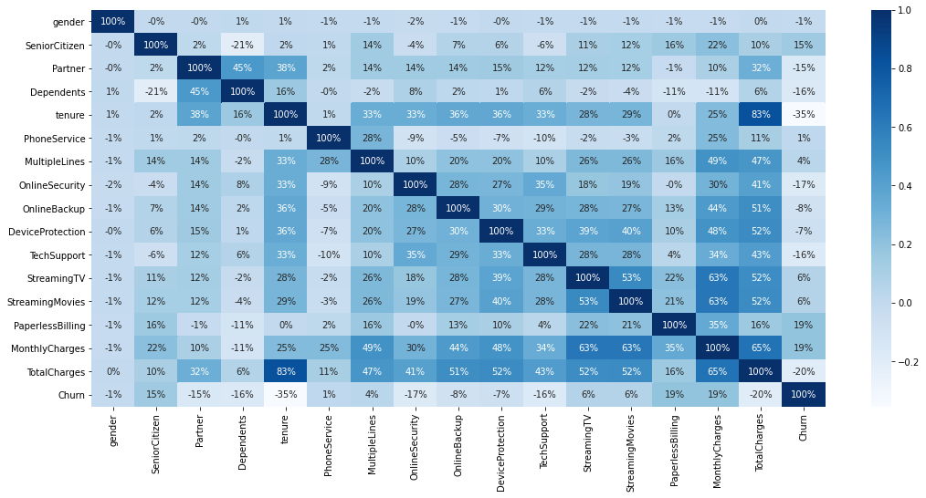

```python
# Check correlation of features in dataset

plt.figure(figsize=(18,8))
#plot sns heat map
sns.heatmap(df.corr(), annot = True, fmt='.0%', cmap="Blues")
```

##### Churn column is positively correlated to columns SeniorCitizen, PhoneService, MultipleLines, StreamingTV, StreamingMovies, PaperlessBilling, and MonthlyCharges.

```python
# Visualize the data on the basis of target variable 'Churn'
df_churn_no = df[df['Churn'] == 0]
df_churn_yes = df[df['Churn'] == 1]
```

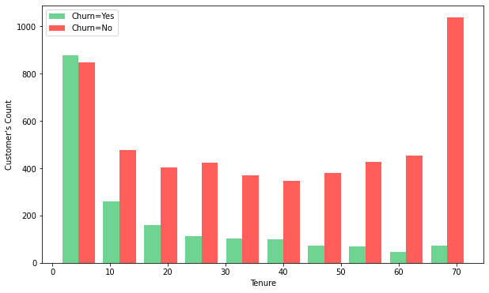

```python
# Churn count distribution on column tenure
plt.figure(figsize=(10,6))
plt.hist([df_churn_yes.tenure, df_churn_no.tenure], color =['#6fd391', '#ff5e5b'], label=['Churn=Yes','Churn=No'])
plt.xlabel("Tenure")
plt.ylabel("Customer's Count")
plt.legend()
```

##### Findings: The customers with longer tenure tend to stay with the company for long time. The customers, who are with the company for more than 70 months(around 6 years), churn rate for those customers is lower.

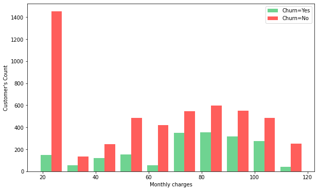

```python
# Churn count distribution on column MonthlyCharges
plt.figure(figsize=(10,6))
plt.hist([df_churn_yes.MonthlyCharges, df_churn_no.MonthlyCharges], color =['#6fd391', '#ff5e5b'], label=['Churn=Yes','Churn=No'])
plt.xlabel("Monthly charges")
plt.ylabel("Customer's Count")
plt.legend()
```

##### Finding: The customers who pay less amount of monthly charges tend to stay with the company for longer.

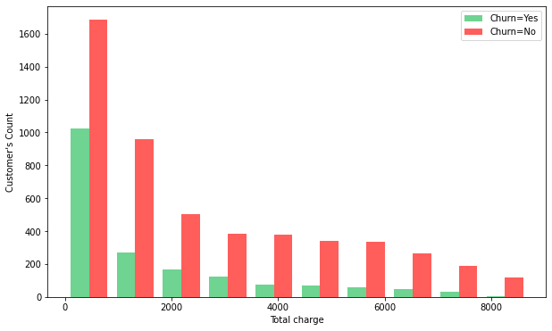

```python
# Churn count distribution on column TotalCharges
plt.figure(figsize=(10,6))
plt.hist([df_churn_yes.TotalCharges, df_churn_no.TotalCharges], color =['#6fd391', '#ff5e5b'], label=['Churn=Yes','Churn=No'])
plt.xlabel("Total charge")
plt.ylabel("Customer's Count")
plt.legend()
```

##### Churn count distribution on other columns

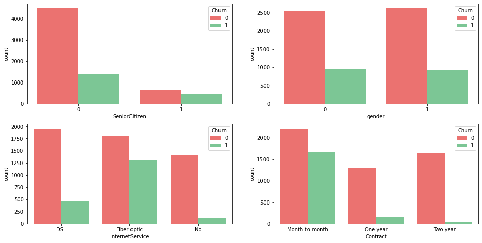

```python
fig, axes = plt.subplots(2, 2, figsize=(16, 8))

#SeniorCitizen : 0:No, 1:Yes ef767a eb4034
sns.countplot('SeniorCitizen', data = df, hue = 'Churn', palette=['#ff5e5b',"#6fd391"], ax=axes[0, 0])
#gender : 0:female, 1:male 6fd3b3 6fd391
sns.countplot('gender', data = df, hue = 'Churn', palette=['#ff5e5b',"#6fd391"], ax=axes[0, 1])

sns.countplot('InternetService', data = df, hue = 'Churn', palette=['#ff5e5b',"#6fd391"], ax=axes[1, 0])
sns.countplot('Contract', data = df, hue = 'Churn', palette=['#ff5e5b',"#6fd391"], ax=axes[1, 1])
```

##### Findings: The Senior Citizens tend to leave the company more often than the non senior citizens. The customer who took the contract for month to month have higher churn rate.

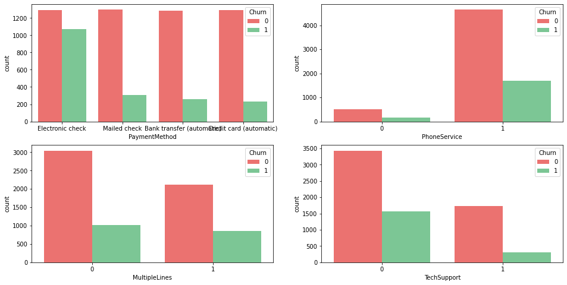

```python
fig, axes = plt.subplots(2, 2, figsize=(16, 8))

sns.countplot('PaymentMethod', data = df, hue = 'Churn', palette=['#ff5e5b',"#6fd391"], ax=axes[0, 0])
sns.countplot('PhoneService', data = df, hue = 'Churn', palette=['#ff5e5b',"#6fd391"], ax=axes[0, 1])

sns.countplot('MultipleLines', data = df, hue = 'Churn', palette=['#ff5e5b',"#6fd391"], ax=axes[1, 0])
sns.countplot('TechSupport', data = df, hue = 'Churn', palette=['#ff5e5b',"#6fd391"], ax=axes[1, 1])
```

##### Findings: The customers who bought the tech support from the company has lower churn rate.

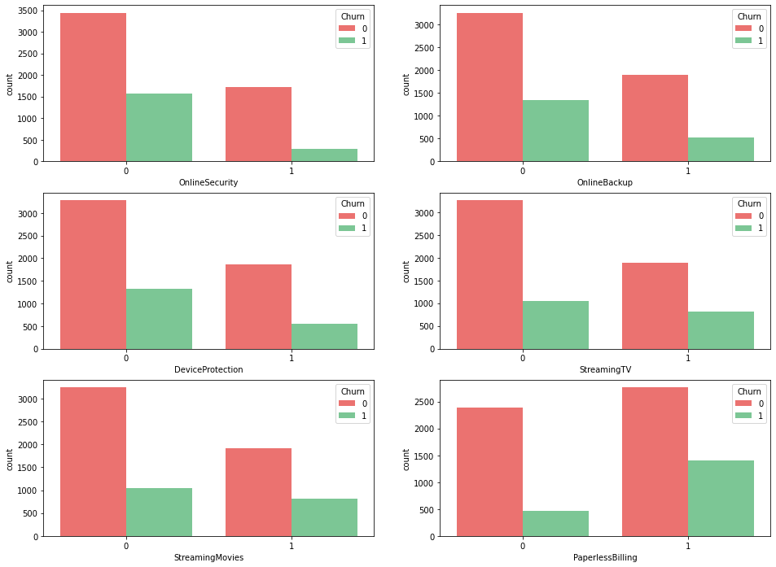

```python
fig, axes = plt.subplots(3, 2, figsize=(16, 12))

sns.countplot('OnlineSecurity', data = df, hue = 'Churn', palette=['#ff5e5b',"#6fd391"], ax=axes[0, 0])
sns.countplot('OnlineBackup', data = df, hue = 'Churn', palette=['#ff5e5b',"#6fd391"], ax=axes[0, 1])

sns.countplot('DeviceProtection', data = df, hue = 'Churn', palette=['#ff5e5b',"#6fd391"], ax=axes[1, 0])
sns.countplot('StreamingTV', data = df, hue = 'Churn', palette=['#ff5e5b',"#6fd391"], ax=axes[1, 1])

sns.countplot('StreamingMovies', data = df, hue = 'Churn', palette=['#ff5e5b',"#6fd391"], ax=axes[2, 0])
sns.countplot('PaperlessBilling', data = df, hue = 'Churn', palette=['#ff5e5b',"#6fd391"], ax=axes[2, 1])
```

### Data modelling:

#### we can get the dummy variable for the remaining categorical columns PaymentMethod, Contract, and InternetService.

```python
df = pd.get_dummies(data = df, columns=['PaymentMethod','Contract','InternetService'])
df.shape
```

```
(7032, 27)
```

```python
df.dtypes
```

```
gender                                       int32
SeniorCitizen                                int64
Partner                                      int32
Dependents                                   int32
tenure                                       int64
PhoneService                                 int32
MultipleLines                                int32
OnlineSecurity                               int32
OnlineBackup                                 int32
DeviceProtection                             int32
TechSupport                                  int32
StreamingTV                                  int32
StreamingMovies                              int32
PaperlessBilling                             int32
MonthlyCharges                             float64
TotalCharges                               float64
Churn                                        int32
PaymentMethod_Bank transfer (automatic)      uint8
PaymentMethod_Credit card (automatic)        uint8
PaymentMethod_Electronic check               uint8
PaymentMethod_Mailed check                   uint8
Contract_Month-to-month                      uint8
Contract_One year                            uint8
Contract_Two year                            uint8
InternetService_DSL                          uint8
InternetService_Fiber optic                  uint8
InternetService_No                           uint8
dtype: object
```

```python
# Scale the columns TotalCharges, MonthlyCharges, and TotalCharges. The other columns are already either 1 or 0.

cols = ['tenure', 'MonthlyCharges', 'TotalCharges']
scaler_fun = preprocessing.MinMaxScaler()
df[cols] = scaler_fun.fit_transform(df[cols])
df[cols]
```

|  | tenure | MonthlyCharges | TotalCharges |
| --- | --- | --- | --- |
| 0 | 0.000000 | 0.115423 | 0.001275 |
| 1 | 0.464789 | 0.385075 | 0.215867 |
| 2 | 0.014085 | 0.354229 | 0.010310 |
| 3 | 0.619718 | 0.239303 | 0.210241 |
| 4 | 0.014085 | 0.521891 | 0.015330 |
| ... | ... | ... | ... |
| 7038 | 0.323944 | 0.662189 | 0.227521 |
| 7039 | 1.000000 | 0.845274 | 0.847461 |
| 7040 | 0.140845 | 0.112935 | 0.037809 |
| 7041 | 0.042254 | 0.558706 | 0.033210 |
| 7042 | 0.915493 | 0.869652 | 0.787641 |

7032 rows × 3 columns

##### splitting the dataset into training and testing dataset

```python
# define independent variable and removing irrelavant columns
x = df.drop(labels=['Churn'], axis = 1)

# dependent Variable
y = df["Churn"]


x_train, x_test, y_train, y_test = train_test_split(x,y,test_size=0.2, random_state=5)
```

```python
print(x_train.shape,x_test.shape)
```

```
(5625, 26) (1407, 26)
```

### Artificial Neural Network:

##### Artificial neural networks (ANNs),also called as neural networks (NNs), are computing systems inspired by the the neural Networks in our brain. An ANN is a collection of connected units or nodes also called neurons, which loosely model the neurons in a biological brain. Deep learning uses artificial neural networks that behaves similarly to the neural networks in our brain. A neural network works when some input data is fed to it and this data is processed via layers of perceptron to produce a output.

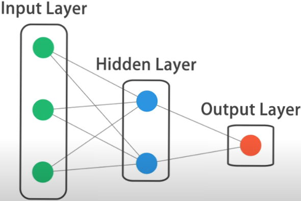

##### Keras: Keras is a powerful and easy-to-use Python library for developing and evaluating deep learning models. It wraps the efficient numerical computation libraries such as TensorFlow and allows to define and train neural network models.

##### https://keras.io/guides/sequential_model/

##### Step:

##### Define Keras Model.

##### Compile Keras Model.

##### Fit Keras Model.

##### Evaluate Keras Model.

##### Make Predictions

##### Create a model using TensorFlow's Keras API :

##### Sequential Model: Sequential Model is appropriate for this dataset because we need to predicted a single output. This model cotains only one input layer , one hidden layer, and a output layer

```python
# Initialising the ANN model
model = Sequential()
```

```python
# Adding the input Layer And the first hidden layer
model.add(Dense(20, kernel_initializer='uniform', activation = 'relu', input_shape=(26,)))

# Adding the output layer
model.add(Dense(units = 1, activation = 'sigmoid'))
```

```python
model.summary()
```

```
Model: "sequential"
_________________________________________________________________
Layer (type)                 Output Shape              Param #
=================================================================
dense (Dense)                (None, 20)                540
_________________________________________________________________
dense_1 (Dense)              (None, 1)                 21
=================================================================
Total params: 561
Trainable params: 561
Non-trainable params: 0
_________________________________________________________________
```

##### Compiling the ANN model

```python
model.compile(optimizer = 'adam', loss = 'binary_crossentropy', metrics = ['accuracy'])
```

##### Fitting the model to training dataset

```python
model.fit(x_train, y_train, epochs = 100)
```

```
<tensorflow.python.keras.callbacks.History at 0x230741f7208>
```

##### Evaluate the model on test dataset

```python
model.evaluate(x_test, y_test)
```

```
[0.439814954996109, 0.7903340458869934]
```

##### Make prediction

```python
y_pred = model.predict(x_test)

# Decode the predicted scaled values again in 1 and 0
y_predicted = []

for i in y_pred:
    if i < 0.5: y_predicted.append(0)
    else: y_predicted.append(1)

# Predicted values
y_predicted[:10]
```

```
[0, 0, 0, 1, 0, 1, 0, 1, 0, 0]
```

```python
# The Real values in test dataset
y_test[:10]
```

```
2660    0
744     0
5579    1
64      1
3287    1
816     1
2670    0
5920    0
1023    0
6087    0
Name: Churn, dtype: int32
```

##### Performance Analysis of predicted values

```python
# Accuracy Score
print("Accuracy= ", accuracy_score(y_test, y_predicted))
print("\n")
```

```
Accuracy=  0.7903340440653873
```

```
Confusion Matrix=
```

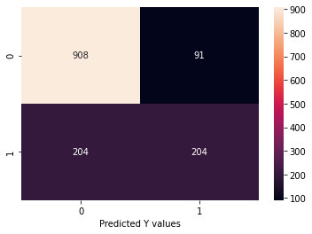

```python
# Confusion matrix

print("Confusion Matrix= ")
con_matrix = tf.math.confusion_matrix(labels=y_test, predictions=y_predicted)
sns.heatmap(con_matrix, annot=True, fmt='d')
plt.xlabel('Predicted Y values')
plt.ylabel('True Values')
```

##### The model is working around 80% accuracy. According to the confusion matrix: the total number of wrong predictions 295. Model worked well with predicting the churn = 0.

```python
# Classificaton Report
print("Classification_Report= ")
print(classification_report(y_test,y_predicted))
```

```
Classification_Report=
              precision    recall  f1-score   support

           0       0.82      0.91      0.86       999
           1       0.69      0.50      0.58       408

    accuracy                           0.79      1407
   macro avg       0.75      0.70      0.72      1407
weighted avg       0.78      0.79      0.78      1407
```

##### Output Visualization

```python
# Adding two columns to the test dataset: the original values of target variable('Churn') and predicted value as well
x_test['Churn'] = y_test
x_test['Churn Predicted'] = y_predicted

x_test
```

|  | gender | SeniorCitizen | Partner | Dependents | tenure | PhoneService | MultipleLines | OnlineSecurity | OnlineBackup | DeviceProtection | ... | PaymentMethod_Electronic check | PaymentMethod_Mailed check | Contract_Month-to-month | Contract_One year | Contract_Two year | InternetService_DSL | InternetService_Fiber optic | InternetService_No | Churn | Churn Predicted |
| --- | --- | --- | --- | --- | --- | --- | --- | --- | --- | --- | --- | --- | --- | --- | --- | --- | --- | --- | --- | --- | --- |
| 2660 | 1 | 0 | 0 | 1 | 0.169014 | 1 | 0 | 1 | 0 | 0 | ... | 0 | 0 | 1 | 0 | 0 | 1 | 0 | 0 | 0 | 0 |
| 744 | 0 | 0 | 0 | 0 | 0.056338 | 1 | 0 | 0 | 0 | 0 | ... | 0 | 0 | 1 | 0 | 0 | 1 | 0 | 0 | 0 | 0 |
| 5579 | 0 | 0 | 1 | 1 | 0.971831 | 1 | 1 | 1 | 1 | 1 | ... | 0 | 0 | 0 | 0 | 1 | 0 | 1 | 0 | 1 | 0 |
| 64 | 0 | 0 | 0 | 0 | 0.112676 | 1 | 1 | 0 | 0 | 0 | ... | 1 | 0 | 1 | 0 | 0 | 0 | 1 | 0 | 1 | 1 |
| 3287 | 1 | 0 | 1 | 1 | 0.253521 | 1 | 1 | 0 | 0 | 0 | ... | 1 | 0 | 0 | 1 | 0 | 0 | 1 | 0 | 1 | 0 |
| ... | ... | ... | ... | ... | ... | ... | ... | ... | ... | ... | ... | ... | ... | ... | ... | ... | ... | ... | ... | ... | ... |
| 2024 | 1 | 0 | 0 | 0 | 0.154930 | 1 | 0 | 0 | 0 | 1 | ... | 1 | 0 | 0 | 1 | 0 | 0 | 1 | 0 | 0 | 0 |
| 4396 | 1 | 1 | 0 | 0 | 0.000000 | 0 | 0 | 0 | 0 | 0 | ... | 1 | 0 | 1 | 0 | 0 | 1 | 0 | 0 | 1 | 1 |
| 4081 | 0 | 0 | 0 | 0 | 0.000000 | 1 | 0 | 0 | 0 | 0 | ... | 1 | 0 | 1 | 0 | 0 | 0 | 1 | 0 | 1 | 1 |
| 1297 | 0 | 0 | 0 | 0 | 0.056338 | 1 | 1 | 0 | 0 | 0 | ... | 1 | 0 | 1 | 0 | 0 | 0 | 1 | 0 | 0 | 1 |
| 4899 | 0 | 0 | 0 | 1 | 0.042254 | 1 | 1 | 0 | 1 | 1 | ... | 0 | 0 | 1 | 0 | 0 | 0 | 1 | 0 | 1 | 1 |

1407 rows × 28 columns

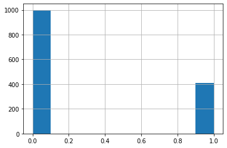

```python
x_test['Churn'].hist()
```

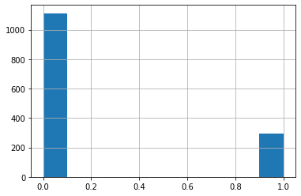

```python
x_test['Churn Predicted'].hist()
```

##### References:

##### https://en.wikipedia.org/wiki/Artificial_neural_network

##### https://keras.io/guides/sequential_model/

##### https://machinelearningmastery.com/tutorial-first-neural-network-python-keras/

##### https://ieeexplore-ieee-org.proxy-harrisburg.klnpa.org/document/8927877 "Deep Learning Based Customer Churn Analysis" by Shulin Cao, Wei Liu, Yuxing Chen, Xiaoyan Zhu,State Key Laboratory of Integrated Services Networks, Xidian University, Xi’an 710071, China